# Praca domowa na 16.01.2017

Tomasz Żółtak

11 stycznia 2017

# Zadanie 1.

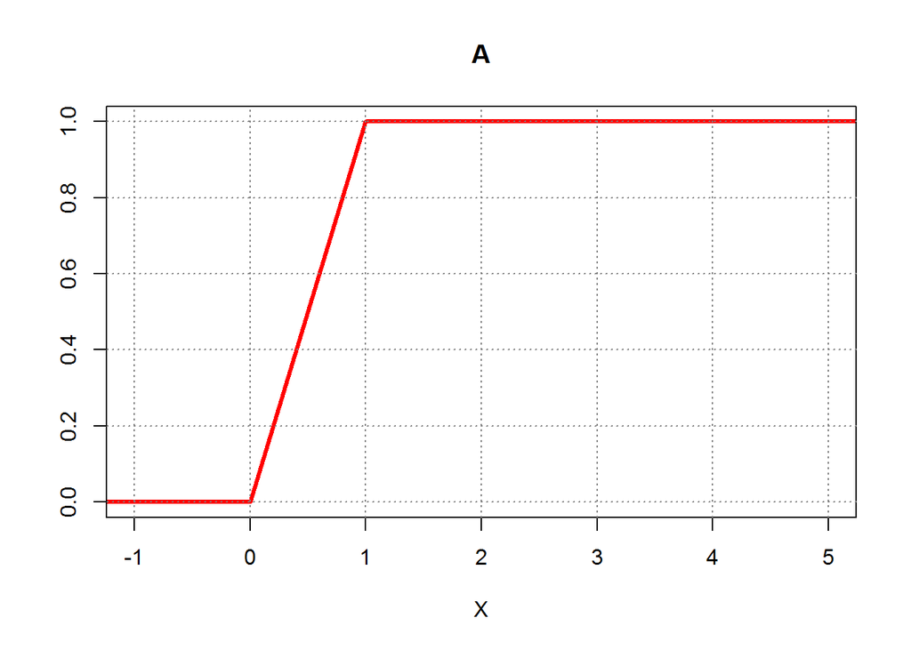

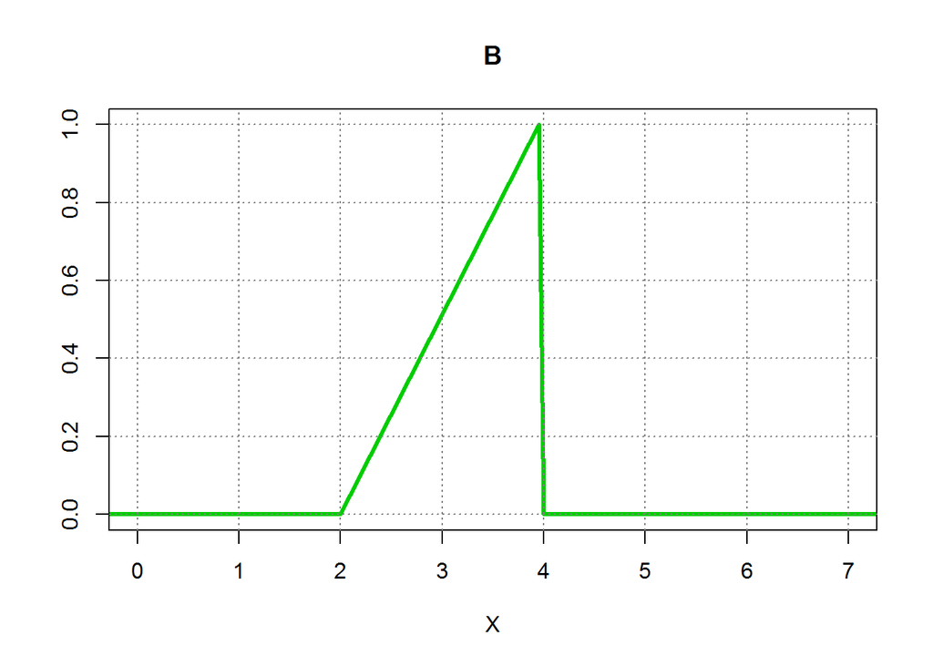

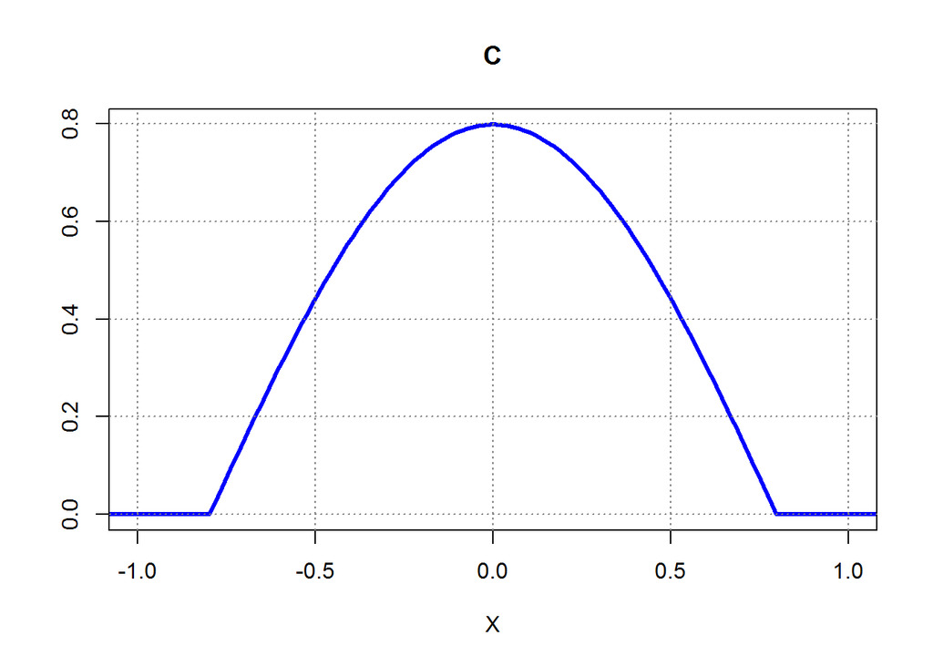

Dla każdego z powyższych wykresów wybierz (usuwając niepoprawną odpowiedź), czy obrazuje on przebieg dystrybuanty, czy funkcji gęstości prawdopodobieństwa. Na jakiej podstawie wyciągnąłeś/ęłaś taki wniosek?

Wykres:

- A: **dystrybuanta/funkcja gęstości prawdopodobieństwa**, bo: **napisz krótkie uzasadnienie**;
- B: **dystrybuanta/funkcja gęstości prawdopodobieństwa**, bo: **napisz krótkie uzasadnienie**;
- C: **dystrybuanta/funkcja gęstości prawdopodobieństwa**, bo: **napisz krótkie uzasadnienie**;

# Zadanie 2.

Dana jest pewna zmienna losowa *W*. Przy każdym z poniższych pytań zdecyduj (usuwając niepoprawną odpowiedź), czy aby odpowiedzieć na nie należy posłużyć się dystrybuantą zmiennej *W*, czy funkcją odwrotną do dystrybuanty zmiennej *W*?

1. Jakie jest *r*, które spełnia warunek: P(W < r) = 0,3? **dystrybuanta/funkcja odwrotna do dystrybuanty**;
2. Jakie jest P(W > -1.8)? **dystrybuanta/funkcja odwrotna do dystrybuanty**;
3. Jakie jest P(3 < W < 5,1)? **dystrybuanta/funkcja odwrotna do dystrybuanty**;

# Zadanie 3.

Przebieg dystrybuanty zmiennej losowej X obrazuje wykres poniżej.

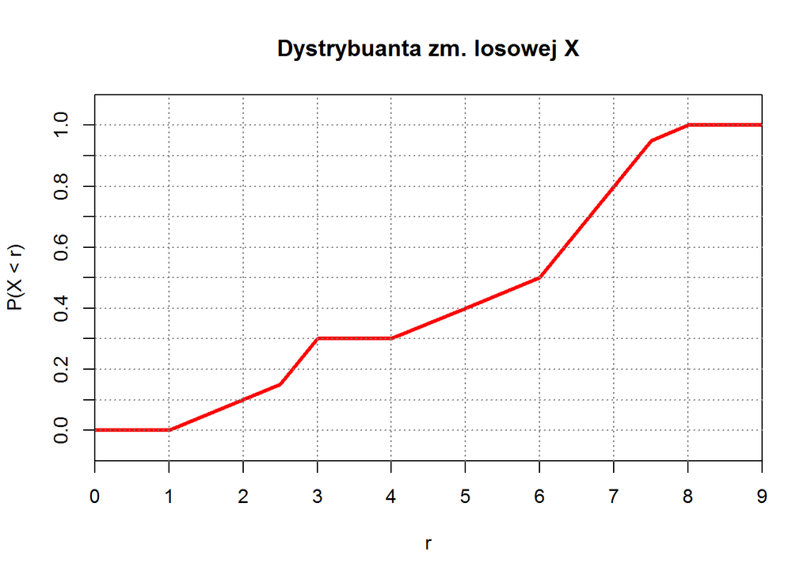

Odpowiedz na pytania:

1. Ile wynosi P(X < 3,6)? **wpisz odpowiedź**
2. Ile wynosi P(X > 2)? **wpisz odpowiedź**
3. Ile wynosi P(2 < X < 7)? **wpisz odpowiedź**
4. Jaka jest wartość *r* spełniająca warunek: P(X > r) = 0,6? **wpisz odpowiedź**
5. Jaka jest wartość *r* spełniająca warunek: P(X < r) = 0,5? **wpisz odpowiedź**

# Zadanie 4.

Przebieg funkcji gęstości prawdopodobieństwa zmiennej losowej Y obrazuje wykres poniżej.

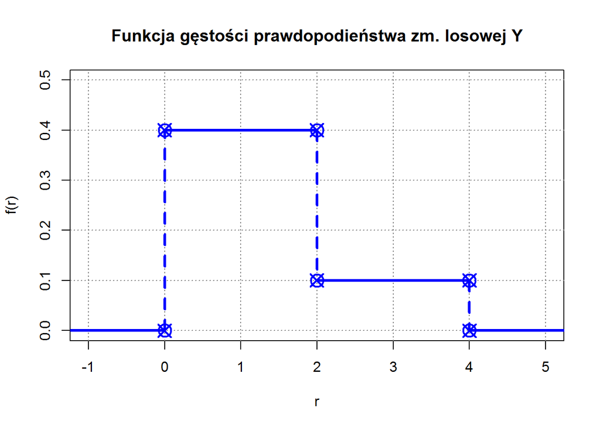

Odpowiedz na pytania:

1. Ile wynosi P(Y < 1)? **wpisz odpowiedź**
2. Ile wynosi P(Y > 2)? **wpisz odpowiedź**
3. Ile wynosi P(1 < Y < 3)? **wpisz odpowiedź**
4. Jaka jest wartość *r* spełniająca warunek: P(Y < r) = 0,8? **wpisz odpowiedź**
5. Jaka jest wartość *r* spełniająca warunek: P(Y > r) = 0,15? **wpisz odpowiedź**

# Czynności końcowe

- Zapisz wyniki swojej pracy (tj. plik “praca_domowa_2017.01.09.Rmd”).
- Zmień jego nazwę na “moje_imie_i_nazwisko_2017.01.09.Rmd”.
- Wyślij go na adres email: **zoltakt@is.uw.edu.pl**